# Data visualization

## 6.1 Exercises

1. What geom would you use to draw a line chart? A boxplot? A histogram? An area chart?

For the line chart, you would use `geom_line()`:

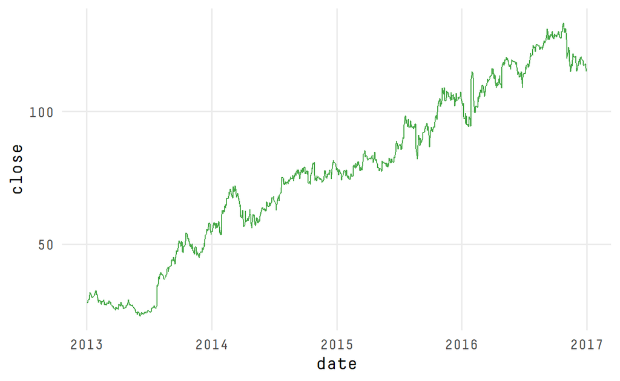

```
tidyquant::FANG %>%
  filter(symbol == "FB") %>%
  ggplot(mapping = aes(x = date, y = close)) +
  geom_line(color = amazing_colors[3])
```

For the boxplot, you would use `geom_boxplot()`:

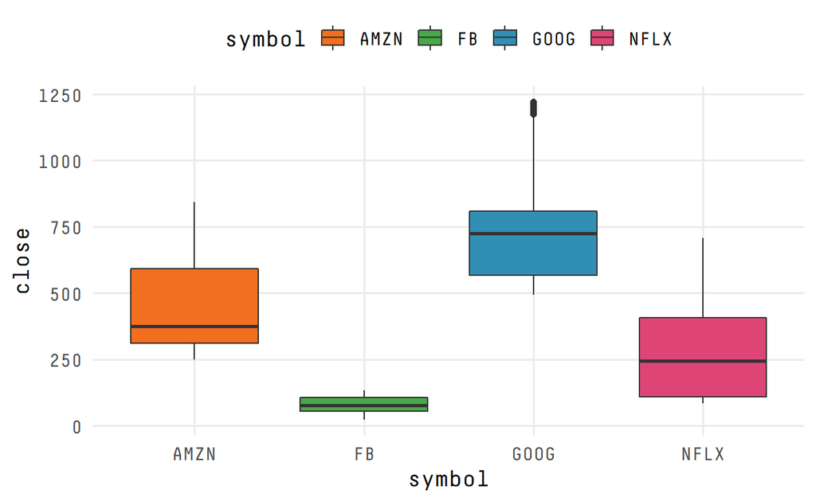

```
tidyquant::FANG %>%
  ggplot(mapping = aes(x = symbol, y = close)) +
  geom_boxplot(aes(fill = symbol)) +
  scale_fill_manual(values = amazing_colors[2:6])
```

For a histogram, you would use `geom_histogram()`:

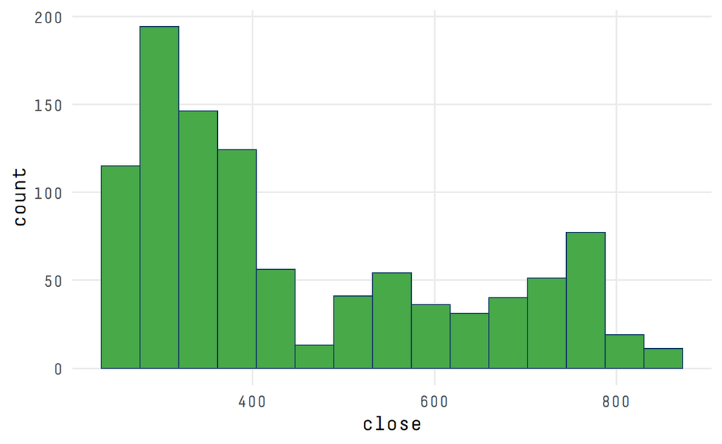

```
tidyquant::FANG %>%
  filter(symbol == "AMZN") %>%
  ggplot(mapping = aes(x = close)) +
  geom_histogram(fill = amazing_colors[3],
                 colour = amazing_colors[1],
                 bins = 15)
```

For an area chart, you would use `geom_area()`:

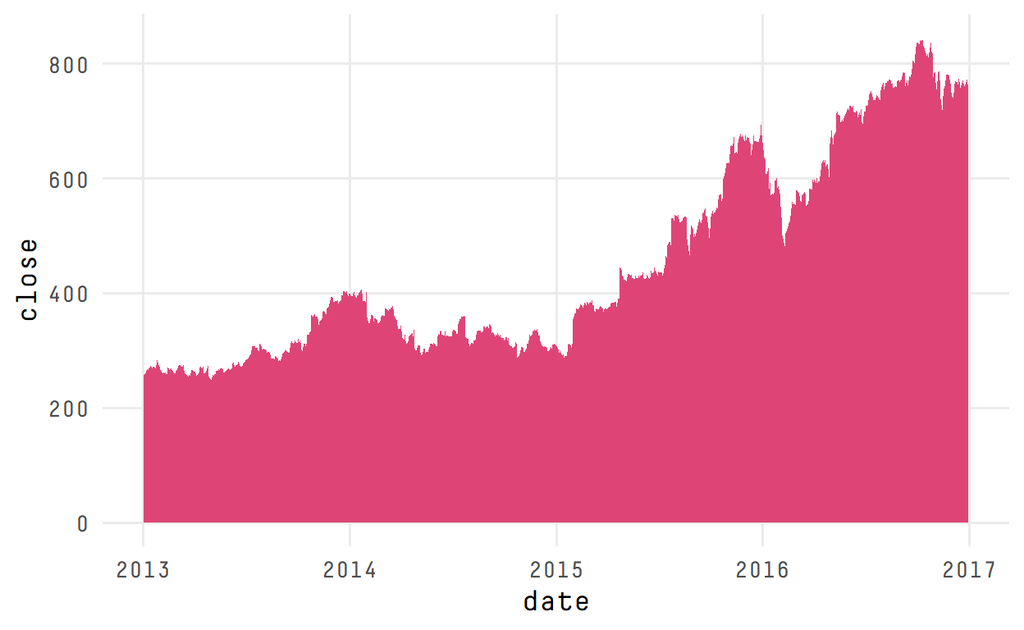

```
tidyquant::FANG %>%
  filter(symbol == "AMZN") %>%
  ggplot(mapping = aes(x = date, y = close)) +
  geom_area(fill = amazing_colors[5])
```

2. Run this code in your head and predict what the output will look like. Then, run the code in R and check your predictions.

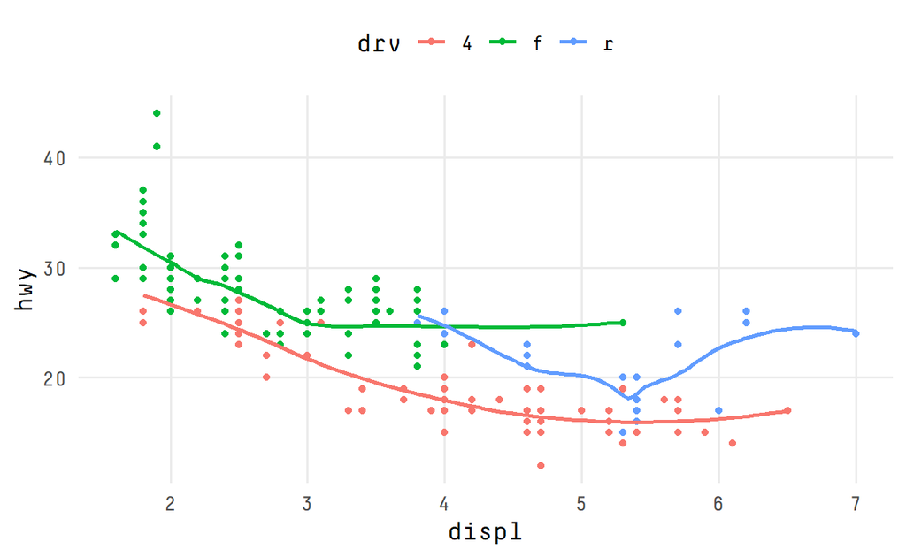

```
ggplot(data = mpg, mapping = aes(x = displ, y = hwy, color = drv)) +
  geom_point() +
  geom_smooth(se = FALSE)
```

3. What does `show.legend = FALSE` do? What happens if you remove it? Why do you think I used it earlier in the chapter?

It removes the legend that is produced by a certain `geom_*()` function.

4. What does the `se` argument to `geom_smooth()` do?

The documentation says that it is used to choose if the *confidence interval* should be computed and displayed (or not, when it’s set to `FALSE`).

5. Will these two graphs look different? Why/why not?

```
ggplot(data = mpg, mapping = aes(x = displ, y = hwy)) +
  geom_point() +
  geom_smooth()

ggplot() +
  geom_point(data = mpg, mapping = aes(x = displ, y = hwy)) +
  geom_smooth(data = mpg, mapping = aes(x = displ, y = hwy))
```

No they won’t they have the exact same mappings and data. The only difference is that the first code uses *global* data and mappings, while the second chunk uses *local* data and mappings.

6. Recreate some graphs:

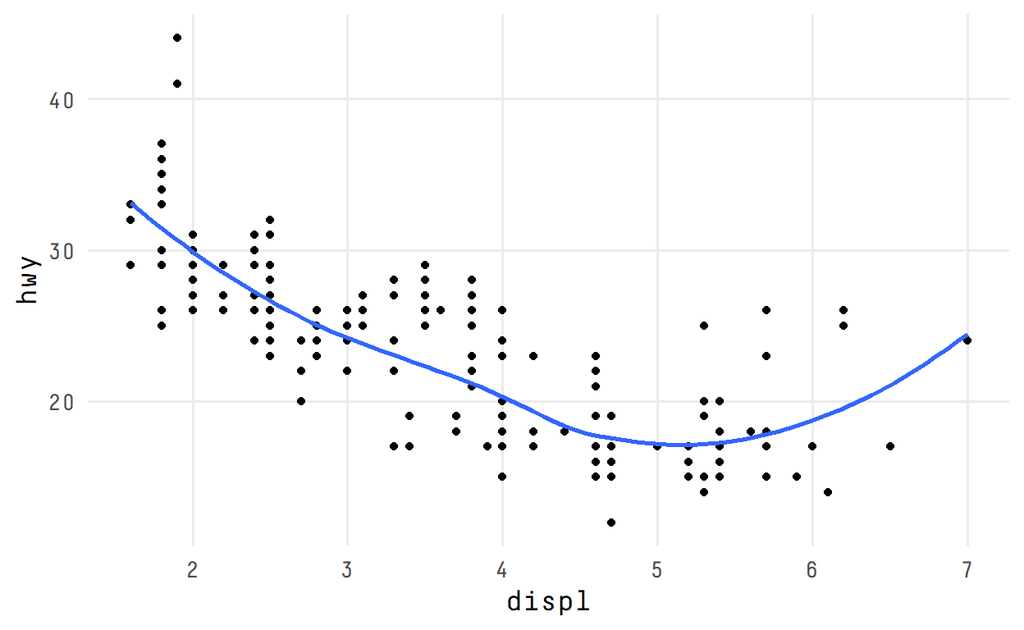

```
mpg %>%
  ggplot(mapping = aes(x = displ, hwy)) +
  geom_point() +
  geom_smooth(se = FALSE)
```

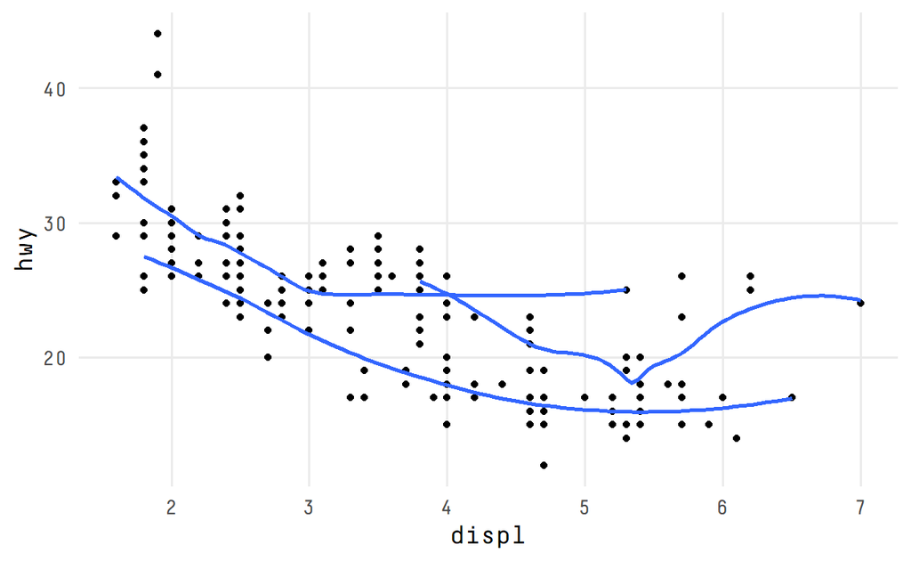

```
mpg %>%
  ggplot(mapping = aes(x = displ, hwy)) +
  geom_point() +
  geom_smooth(mapping = aes(group = drv),
              se = FALSE)
```

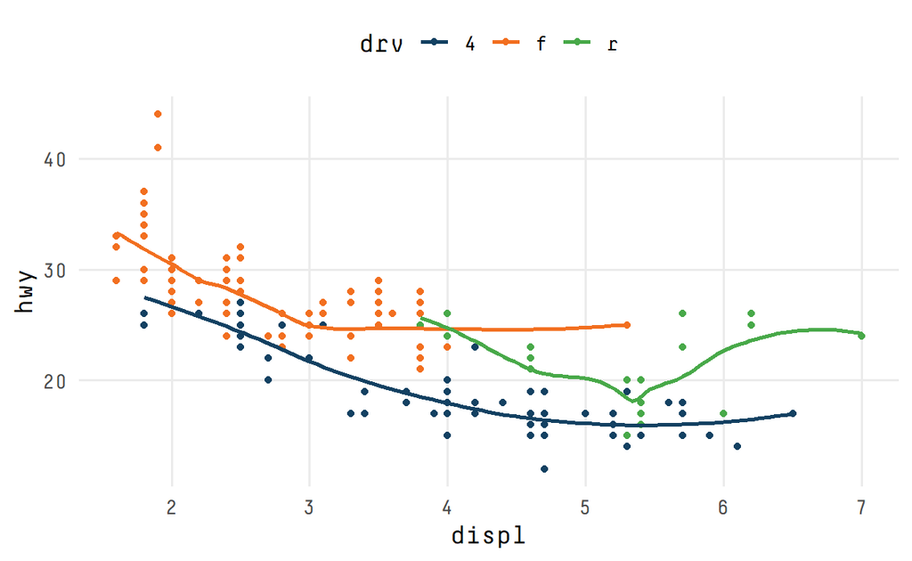

```
mpg %>%

  # Color is mapped in both geoms, so we can set it globally
  ggplot(mapping = aes(x = displ, y = hwy, colour = drv)) +
  geom_point() +
  geom_smooth(se = FALSE) +
  scale_color_manual(values = amazing_colors)
```

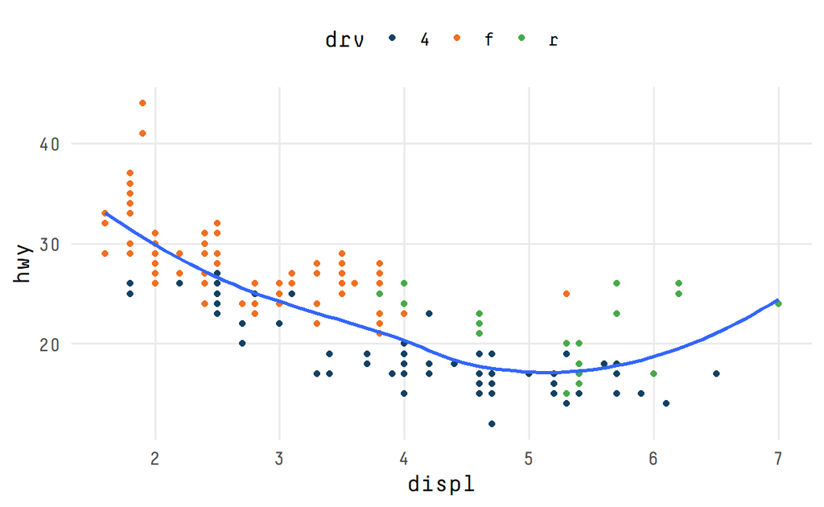

```
mpg %>%
  ggplot(mapping = aes(x = displ, y = hwy)) +

  # Color is only mapped in the geom_point() geom
  geom_point(mapping = aes(colour = drv)) +
  geom_smooth(se = FALSE) +
  scale_color_manual(values = amazing_colors)
```

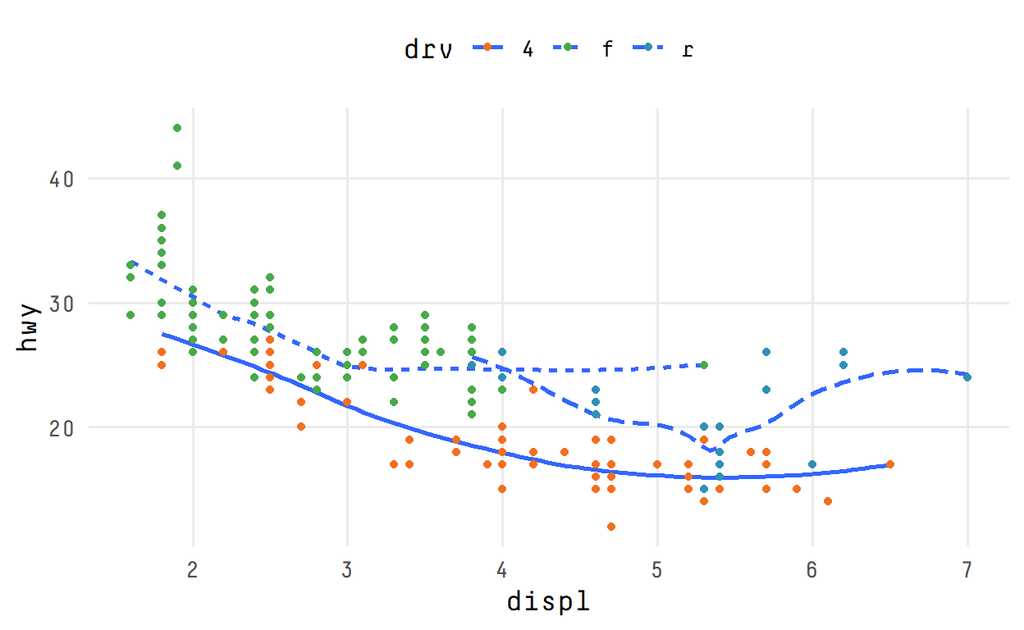

```
mpg %>%
  ggplot(mapping = aes(x = displ, y = hwy)) +
  geom_smooth(mapping = aes(linetype = drv),
              se = FALSE) +
  geom_point(mapping = aes(colour = drv)) +
  scale_color_manual(values = amazing_colors[2:4])
```

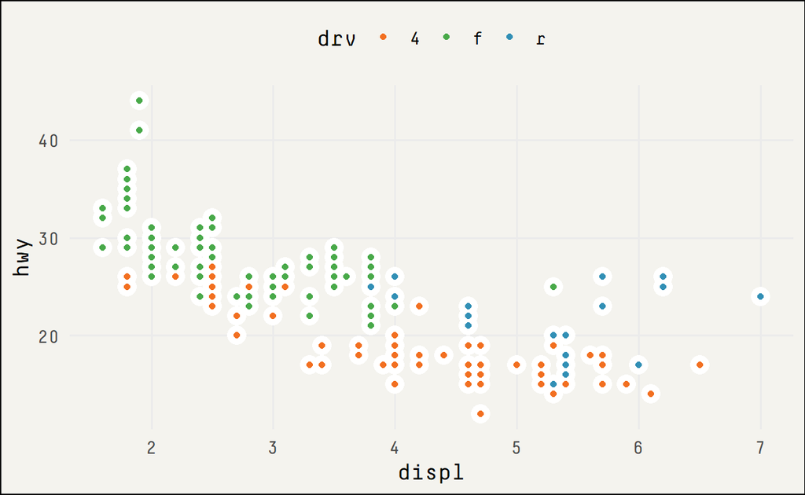

```
mpg %>%
  ggplot(mapping = aes(x = displ, y = hwy, colour = drv)) +

  # The trick is to use two geom_point() geoms
  geom_point(colour = "white", size = 5) +
  geom_point() +
  scale_color_manual(values = amazing_colors[2:4]) +
  theme(
    plot.background = element_rect(fill = "#F4F3EE")
  )
```

[output not shown]

## 7.Statistical Transformations

For this section, the `diamonds` dataset that comes in `ggplot2` is used. It contains information about ~54,000 diamonds, including the `price`, `carat`, `color`, `clarity`, and `cut` of each diamond.

On the following chart, the *x-axis* displays `cut` while the *y-axis* displays the `count` variable. However, the `count` variable **is not present in the data**.

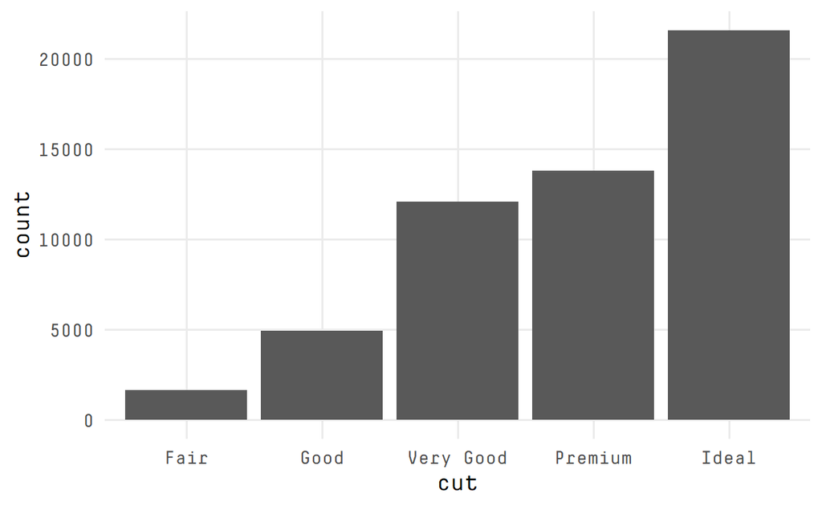

```
diamonds %>%
  ggplot() +
  geom_bar(mapping = aes(x = cut))
```

Where does count come from? Many graphs – like scatterplots – plot the raw values of your dataset. Other graphs, like bar charts, calculate new values to plot:

- bar charts, histograms, and frequency polygons bin your data and then plot bin counts, the number of points that fall in each bin.
- smoothers fit a model to your data and then plot predictions from the model.
- boxplots compute a robust summary of the distribution and then display a specially formatted box.

## 7.1 What is a *stat*

The algorithm that these plots use to calculate new values from existing data is called a **stat** – which is short for *statistical transformations*. A *stat* is a function that **builds new variables to be plotted**.

### Which stat is used

You can learn which stat a geom uses by inspecting the default value for the `stat` argument. For example, `?geom_bar` shows that the default value for `stat` is `stat = "count"`, which means that `geom_bar()` uses `stat_count()`. The documentation for `?geom_bar` also shows a section for *Computed variables* which details the variables that are computed by the `stat_count()` function – in this case, `count` and `prop`.

### Using geoms or stats

You can *generally* use *geoms* and *stats* **interchangeably**. For example, you can recreate the above chart with a `stat_count()` call:

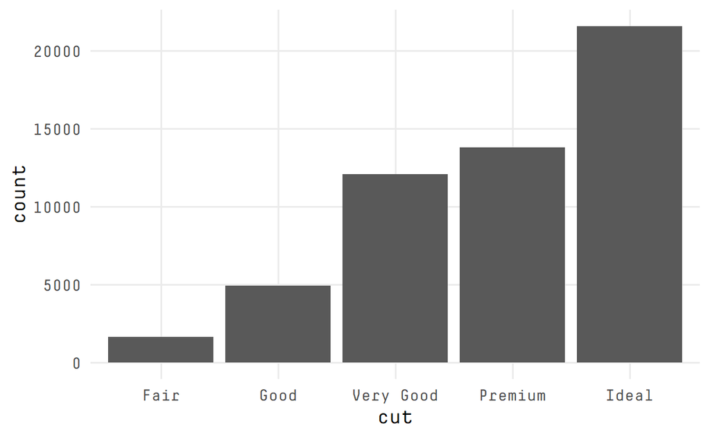

```
diamonds %>%
  ggplot() +
  stat_count(mapping = aes(x = cut))
```

This works because every geom has a default stat; and every stat has a default geom. This means that you can typically use geoms without worrying about the underlying statistical transformation. There are three reasons you might need to use a *stat* explicitly:

1. **Overriding the default stat**: using a different-than-default *stat* could be useful because it allows you to map a different metrics to the *y-axis*. For example, one can change the default `stat_count` in a `geom_bar()` *geom* and use the `stat_identity()` *stat* to map the *y-axis* height to the values of a *y-variable* specified in the `aes()` function. You may want to do this if you had other kind of *frequencies* already present in your data. For example:

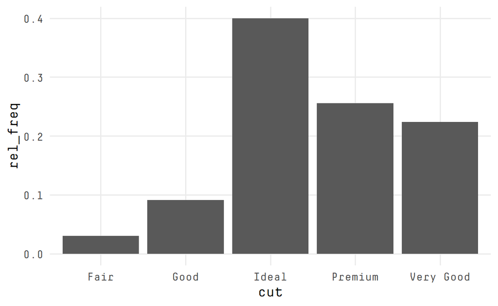

```
tribble(
  ~cut,         ~freq,
  "Fair",       1610,
  "Good",       4906,
  "Very Good",  12082,
  "Premium",    13791,
  "Ideal",      21551
) %>%

  # Create a relative frequency column
  mutate(rel_freq = freq / sum(freq)) %>%

  ggplot(mapping = aes(x = cut, y = rel_freq)) +

  # Map the y-axis to the rel_freq column
  geom_bar(stat = "identity")
```

2. **Using *stats* as *aesthetics***: it could be useful to map certain *stats* to the `aes()` function. You could choose between the *Computed variables* section in the *help* section. The following is a nifty, little trick to plot a relative frequency plot:

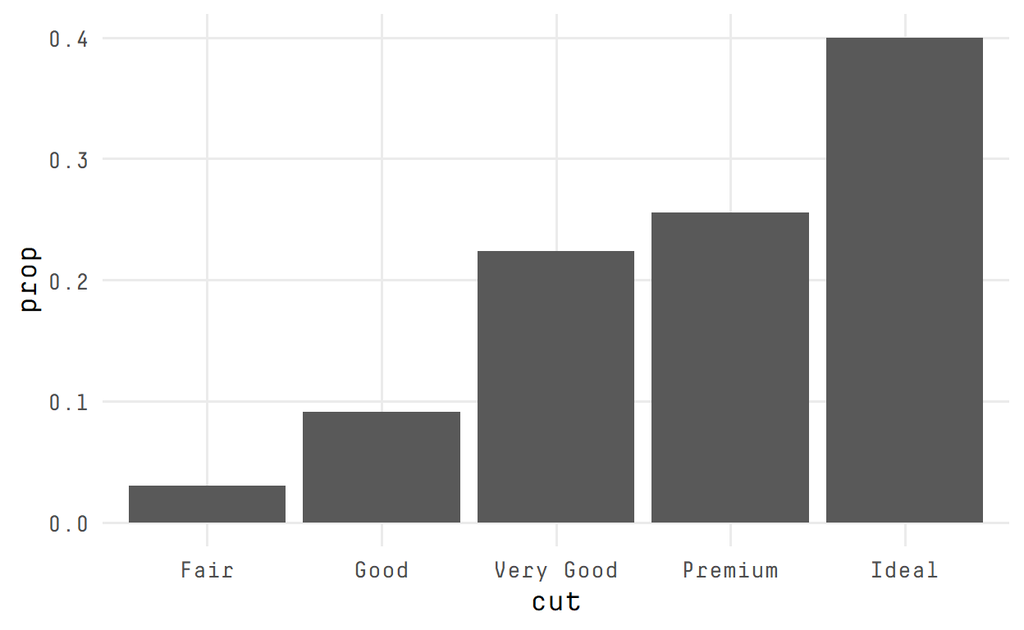

```
diamonds %>%
  ggplot() +
  geom_bar(
    mapping = aes(x = cut,

                  # We map the stat "groupwise proportion" to the y-axis
                  y = stat(prop),

                  # Why do we need this aesthetic?????
                  group = 1)
  )
```

3. **Getting more out of statistical transformations**: the best example is getting a *3-number-summary* of your data with the `stat_summary()` *stat*.

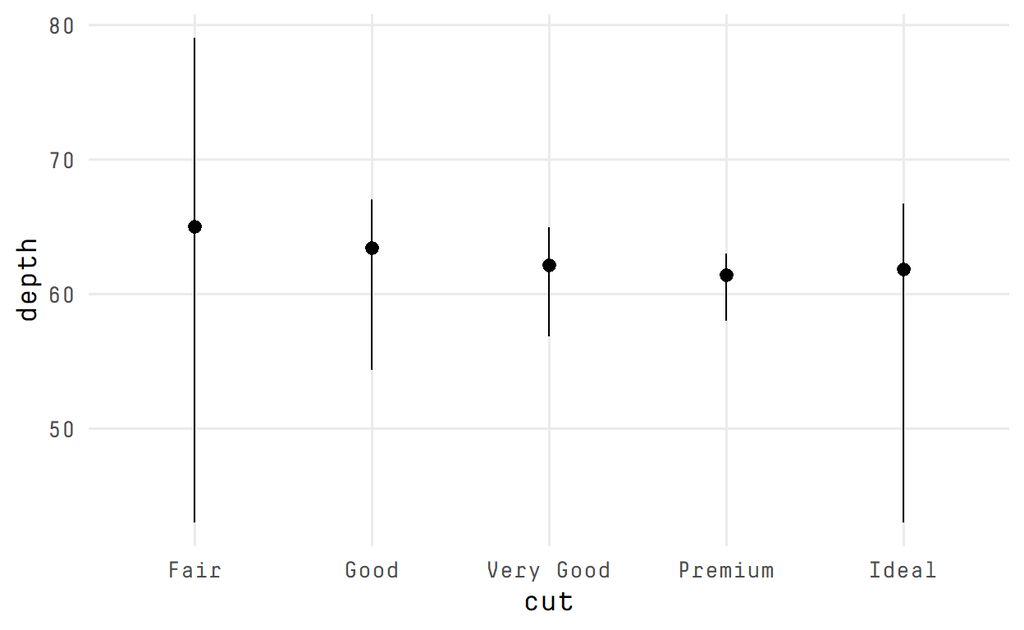

```
diamonds %>%
  ggplot(mapping = aes(x = cut, y = depth)) +
  stat_summary(
    fun.min = min,
    fun.max = max,
    fun = median
  )
```

## 7.2 Exercises

1. What is the default geom associated with `stat_summary()`? How could you rewrite the previous plot to use that geom function instead of the stat function?

   The *geom* used appears to be `pointrange`. The following code produces the same plot as before:

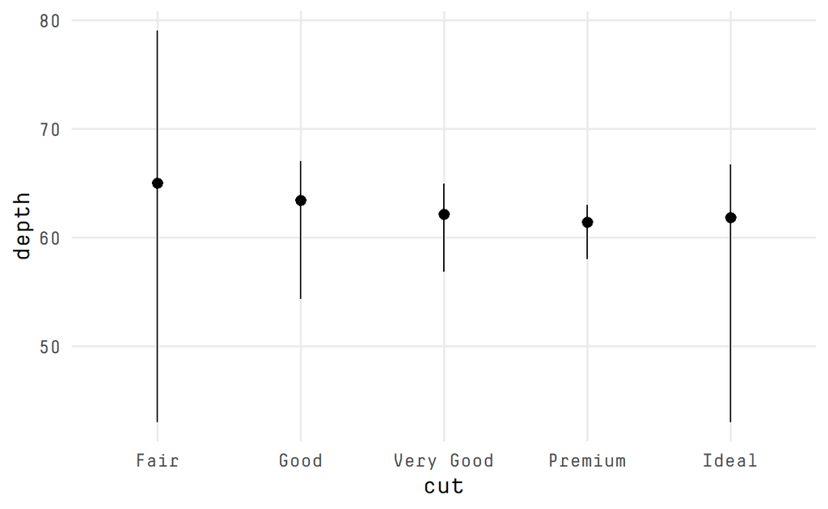

```
diamonds %>%
  ggplot(mapping = aes(x = cut, y = depth)) +
  geom_pointrange(
      stat = "summary",
      fun = median,
      fun.min = min,
      fun.max = max
  )
```

The default stat for `geom_pointrange()` is `identity()` but we can add the argument `stat = "summary"` to use `stat_summary()` instead of `stat_identity()`.

2. What does `geom_col()` do? How is it different to `geom_bar()`?

`geom_col()` will represent values of the data in the *y-axis*, so it’s similar to using `geom_bar(stat = "identity")`. On the other hand, `geom_bar()` makes the height of the bars proportional to the number of cases of each categorical variable (i.e. it *counts* them).

Another difference is that `geom_col()`’s default *stat* is `stat_identity()`, which leaves the data as is; while `geom_bar()`’s default *stat* is `stat_count()`, which counts the data.

3. Most geoms and stats come in pairs that are almost always used in concert. Read through the documentation and make a list of all the pairs. What do they have in common?
4. What variables does `stat_smooth()` compute? What parameters control its behavior?

`stat_smooth()` computes four variables:

1. `y`: predicted value.
2. `ymin`: lower pointwise confidence interval around the mean
3. `ymax`: upper pointwise confidence interval around the mean
4. `se`: standard error

The parameters that control `stat_smooth()` are:

1. `n`: Number of points at which to evaluate smoother.
2. `method`: Smoothing method (function) to use.
3. `formula`: Formula to use in smoothing function.
4. `se`: Display confidence interval around smooth? `TRUE` is default.
5. `span`: Controls the amount of smoothing for the default *loess* smoother. Larger numbers produce smoother lines.
6. `fullrange`: Should the fit span the full range of the plot, or just the data?
7. `level`: Level of confidence interval to use (0.95 by default).

and others (but less important, such as `na.rm`).

5. In our proportion bar chart, we need to set `group = 1`. Why? In other words what is the problem with these two graphs?

If `group = 1` is not included, then all the bars in the plot will have the same height, a height of 1. The function `geom_bar()` assumes that the groups are equal to the `x` values… and since the stat computes the counts within each group… the proportion of each group is 100% (or 1).

`group="whatever"` is a “dummy” grouping to override the default behavior, which (here) is to group by `cut` and in general is to group by the x variable. The default for `geom_bar` is to group by the x variable in order to separately count the number of rows in each level of the x variable. For example, here, the default would be for `geom_bar` to return the number of rows with `cut` equal to “Fair”, “Good”, etc.

However, if we want proportions, then we need to consider all levels of `cut` together. In the second plot, the data are first grouped by `cut`, so each level of `cut` is considered separately. The proportion of Fair in Fair is 100%, as is the proportion of Good in Good, etc. `group=1` (or `group="x"`, etc.) prevents this, so that the proportions of each level of cut will be relative to all levels of cut.

The problem with these two plots is that the proportions are calculated within the groups.

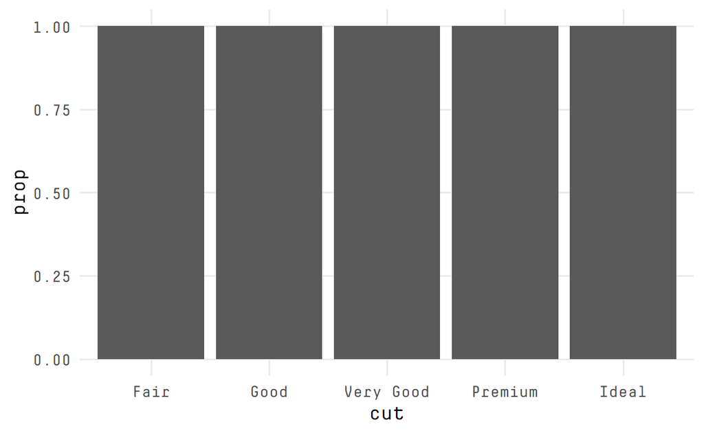

```
ggplot(data = diamonds) +
  geom_bar(mapping = aes(x = cut, y = after_stat(prop)))
```

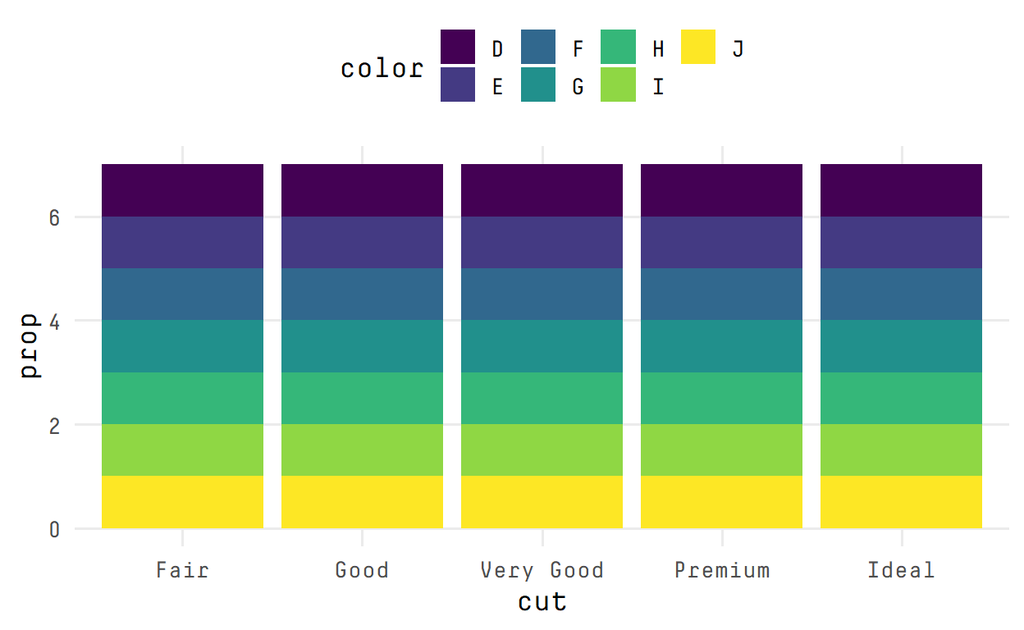

```
ggplot(data = diamonds) +
  geom_bar(mapping = aes(x = cut, fill = color, y = after_stat(prop)))
```

## 8.Position Adjustments

You can color a bar chart using either the `colour` aesthetic, or, more usefully, `fill`:

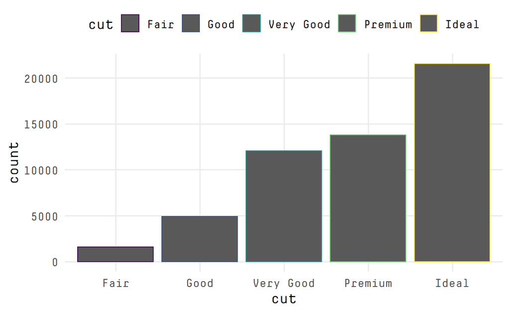

```
diamonds %>%
  ggplot() +
  geom_bar(aes(x = cut, color = cut))
```

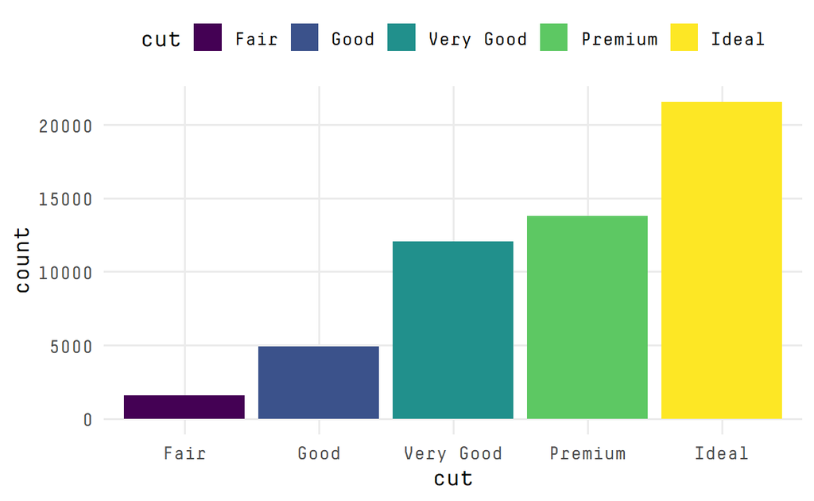

```
diamonds %>%
  ggplot() +
  geom_bar(aes(x = cut, fill = cut))
```

Note that, in both cases, the variable mapped to `x` is the same mapped to `fill` or `color`. If you map these last aesthetics to a different variable, you get stacked bars:

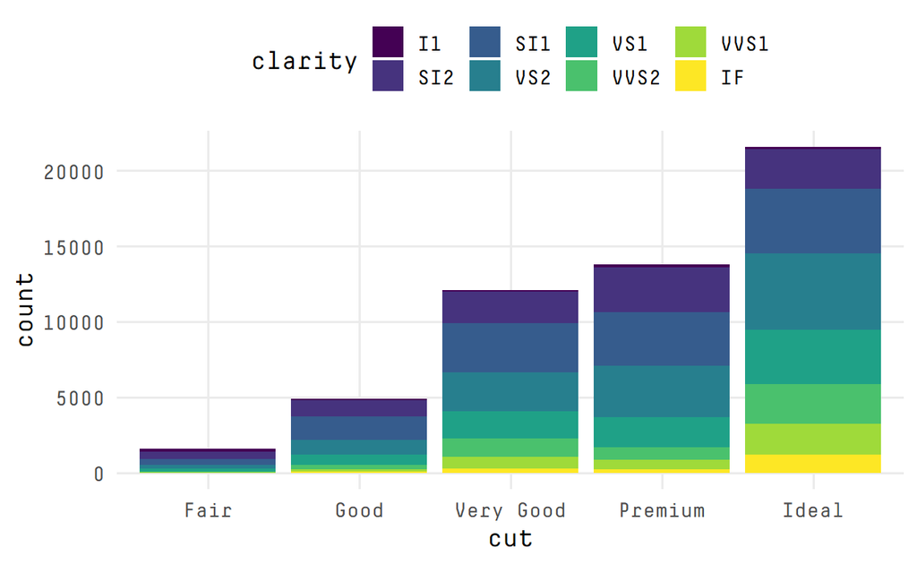

```
diamonds %>%
  ggplot() +
  geom_bar(mapping = aes(x = cut, fill = clarity))
```